# co-occupancy

# Step 3: test co-occupancy variables —————————————

```r
# lelevation
winter_LW_OF_200 <- c('~CLC_forest', '~Z',
                       '~Z')

winter_LW_200 <- occuMulti(winter_LW_det, winter_LW_OF_200, winter_occ_data)
summary(winter_LW_200)
```

```
##
## Call:
## occuMulti(detformulas = winter_LW_det, stateformulas = winter_LW_OF_200,
##     data = winter_occ_data, maxOrder = 2L)
##
## Occupancy (logit-scale):
##                         Estimate    SE      z P(>|z|)
## [Lynx] (Intercept)         0.728 0.481  1.514  0.1300
## [Lynx] CLC_forest          0.364 0.314  1.159  0.2464
## [Wolf] (Intercept)        -1.280 0.958 -1.337  0.1813
## [Wolf] Z                  -1.796 0.939 -1.912  0.0559
## [Lynx:Wolf] (Intercept)    1.125 1.016  1.107  0.2681
## [Lynx:Wolf] Z              0.431 0.738  0.584  0.5595
##
## Detection (logit-scale):
##                    Estimate    SE      z  P(>|z|)
## [Lynx] (Intercept)   -1.071 0.146 -7.341 2.13e-13
## [Lynx] Wolf           0.679 0.370  1.837 6.62e-02
## [Lynx] diststream     0.244 0.128  1.901 5.73e-02
## [Wolf] (Intercept)   -1.522 0.278 -5.469 4.53e-08
## [Wolf] Lynx           0.509 0.387  1.315 1.89e-01
## [Wolf] diststream    -0.205 0.222 -0.921 3.57e-01
##
## AIC: 767.8131
## Number of sites: 64
## optim convergence code: 0
## optim iterations: 42
## Bootstrap iterations: 0
```

```r
# forest habitat
winter_LW_OF_201 <- c('~CLC_forest', '~Z',
                       '~CLC_forest')

winter_LW_201 <- occuMulti(winter_LW_det, winter_LW_OF_201, winter_occ_data)
summary(winter_LW_201)
```

```
##
## Call:
## occuMulti(detformulas = winter_LW_det, stateformulas = winter_LW_OF_201,
##     data = winter_occ_data, maxOrder = 2L)
##
## Occupancy (logit-scale):
##                         Estimate    SE      z P(>|z|)
## [Lynx] (Intercept)        0.7177 0.477  1.504  0.1325
## [Lynx] CLC_forest         0.3399 0.395  0.860  0.3897
## [Wolf] (Intercept)       -1.0713 0.799 -1.340  0.1801
## [Wolf] Z                 -1.3866 0.562 -2.467  0.0136
## [Lynx:Wolf] (Intercept)   0.8586 0.836  1.026  0.3047
## [Lynx:Wolf] CLC_forest    0.0463 0.428  0.108  0.9138
##
## Detection (logit-scale):
##                    Estimate    SE      z  P(>|z|)
## [Lynx] (Intercept)   -1.070 0.146 -7.318 2.51e-13
## [Lynx] Wolf           0.680 0.369  1.842 6.55e-02
## [Lynx] diststream     0.247 0.128  1.930 5.35e-02
## [Wolf] (Intercept)   -1.506 0.272 -5.531 3.19e-08
## [Wolf] Lynx           0.500 0.386  1.295 1.95e-01
## [Wolf] diststream    -0.197 0.223 -0.884 3.76e-01
##
## AIC: 768.1552
## Number of sites: 64
## optim convergence code: 0
## optim iterations: 43
## Bootstrap iterations: 0
```

```r
# lynx:wolf movement
winter_LW_OF_202 <- c('~CLC_forest', '~Z',
                       '~TRI5')

winter_LW_202 <- occuMulti(winter_LW_det, winter_LW_OF_202, winter_occ_data)
summary(winter_LW_202)
```

```
##
## Call:
## occuMulti(detformulas = winter_LW_det, stateformulas = winter_LW_OF_202,
##     data = winter_occ_data, maxOrder = 2L)
##
## Occupancy (logit-scale):
##                         Estimate    SE      z P(>|z|)
## [Lynx] (Intercept)         0.726 0.469  1.548 0.12164
## [Lynx] CLC_forest          0.344 0.314  1.094 0.27413
## [Wolf] (Intercept)        -1.165 0.798 -1.459 0.14451
## [Wolf] Z                  -1.359 0.524 -2.595 0.00946
## [Lynx:Wolf] (Intercept)    0.898 0.841  1.067 0.28584
## [Lynx:Wolf] TRI5           0.260 0.340  0.764 0.44477
##
## Detection (logit-scale):
##                    Estimate    SE      z  P(>|z|)
## [Lynx] (Intercept)   -1.073 0.146 -7.349 1.99e-13
## [Lynx] Wolf           0.680 0.369  1.842 6.54e-02
## [Lynx] diststream     0.243 0.129  1.894 5.83e-02
## [Wolf] (Intercept)   -1.479 0.268 -5.510 3.59e-08
## [Wolf] Lynx           0.494 0.386  1.281 2.00e-01
## [Wolf] diststream    -0.186 0.223 -0.833 4.05e-01
##
## AIC: 767.5613
## Number of sites: 64
## optim convergence code: 0
## optim iterations: 45
## Bootstrap iterations: 0
```

```r
# road density
winter_LW_OF_203<- c('~CLC_forest', '~Z',
                      '~denslocalr')

winter_LW_203 <- occuMulti(winter_LW_det, winter_LW_OF_203, winter_occ_data)
summary(winter_LW_203)
```

```
##
## Call:
## occuMulti(detformulas = winter_LW_det, stateformulas = winter_LW_OF_203,
##     data = winter_occ_data, maxOrder = 2L)
##
## Occupancy (logit-scale):
##                         Estimate    SE     z P(>|z|)
## [Lynx] (Intercept)         0.720 0.472  1.53 0.12700
## [Lynx] CLC_forest          0.387 0.319  1.21 0.22556
## [Wolf] (Intercept)        -1.233 0.817 -1.51 0.13104
## [Wolf] Z                  -1.372 0.529 -2.59 0.00958
## [Lynx:Wolf] (Intercept)    0.956 0.866  1.10 0.26967
## [Lynx:Wolf] denslocalr     0.509 0.349  1.46 0.14500
##
## Detection (logit-scale):
##                    Estimate    SE      z  P(>|z|)
## [Lynx] (Intercept)   -1.079 0.147 -7.352 1.95e-13
## [Lynx] Wolf           0.675 0.369  1.828 6.75e-02
## [Lynx] diststream     0.247 0.128  1.934 5.32e-02
## [Wolf] (Intercept)   -1.486 0.269 -5.533 3.15e-08
## [Wolf] Lynx           0.492 0.385  1.277 2.02e-01
## [Wolf] diststream    -0.211 0.220 -0.961 3.37e-01
##
## AIC: 765.8801
## Number of sites: 64
## optim convergence code: 0
## optim iterations: 45
## Bootstrap iterations: 0
```

```r
# roads + forest habitat
winter_LW_OF_204 <- c('~CLC_forest', '~Z',
                       '~denslocalr+CLC_forest')

winter_LW_204 <- occuMulti(winter_LW_det, winter_LW_OF_204, winter_occ_data)
summary(winter_LW_204)
```

```
##
## Call:
## occuMulti(detformulas = winter_LW_det, stateformulas = winter_LW_OF_204,
##     data = winter_occ_data, maxOrder = 2L)
##
## Occupancy (logit-scale):
##                         Estimate    SE      z P(>|z|)
## [Lynx] (Intercept)         0.708 0.466  1.519 0.12879
## [Lynx] CLC_forest          0.321 0.376  0.853 0.39364
## [Wolf] (Intercept)        -1.250 0.808 -1.548 0.12169
## [Wolf] Z                  -1.361 0.526 -2.587 0.00967
## [Lynx:Wolf] (Intercept)    0.961 0.859  1.119 0.26319
## [Lynx:Wolf] denslocalr     0.527 0.356  1.478 0.13947
## [Lynx:Wolf] CLC_forest     0.139 0.440  0.315 0.75302
##
## Detection (logit-scale):
##                    Estimate    SE      z  P(>|z|)
## [Lynx] (Intercept)   -1.075 0.147 -7.336 2.20e-13
## [Lynx] Wolf           0.671 0.369  1.819 6.90e-02
## [Lynx] diststream     0.246 0.128  1.925 5.42e-02
## [Wolf] (Intercept)   -1.485 0.269 -5.524 3.31e-08
## [Wolf] Lynx           0.489 0.385  1.272 2.03e-01
## [Wolf] diststream    -0.208 0.222 -0.939 3.48e-01
##
## AIC: 767.7803
## Number of sites: 64
## optim convergence code: 0
## optim iterations: 46
## Bootstrap iterations: 0
```

```r
# roads + forest habtat + movement
winter_LW_OF_205 <-  c('~CLC_forest', '~Z',
                        '~denslocalr+CLC_forest+TRI5')

winter_LW_205 <- occuMulti(winter_LW_det, winter_LW_OF_205, winter_occ_data)
summary(winter_LW_205)
```

```
##
## Call:
## occuMulti(detformulas = winter_LW_det, stateformulas = winter_LW_OF_205,
##     data = winter_occ_data, maxOrder = 2L)
##
## Occupancy (logit-scale):
##                         Estimate    SE      z P(>|z|)
## [Lynx] (Intercept)         0.710 0.461  1.541 0.12340
## [Lynx] CLC_forest          0.315 0.369  0.853 0.39365
## [Wolf] (Intercept)        -1.326 0.819 -1.619 0.10547
## [Wolf] Z                  -1.340 0.494 -2.714 0.00665
## [Lynx:Wolf] (Intercept)    0.999 0.870  1.148 0.25088
## [Lynx:Wolf] denslocalr     0.499 0.352  1.419 0.15595
## [Lynx:Wolf] CLC_forest     0.117 0.434  0.268 0.78843
## [Lynx:Wolf] TRI5           0.224 0.360  0.621 0.53454
##
## Detection (logit-scale):
##                    Estimate    SE     z  P(>|z|)
## [Lynx] (Intercept)   -1.075 0.147 -7.34 2.18e-13
## [Lynx] Wolf           0.669 0.369  1.81 6.98e-02
## [Lynx] diststream     0.242 0.129  1.88 5.99e-02
## [Wolf] (Intercept)   -1.461 0.266 -5.50 3.89e-08
## [Wolf] Lynx           0.481 0.384  1.25 2.11e-01
## [Wolf] diststream    -0.197 0.222 -0.89 3.74e-01
##
## AIC: 769.3829
## Number of sites: 64
## optim convergence code: 0
## optim iterations: 50
## Bootstrap iterations: 0
```

```r
# roads  forest habitat + elevation
winter_LW_OF_206 <-  c('~CLC_forest', '~Z',
                       '~denslocalr+CLC_forest+Z')

winter_LW_206 <- occuMulti(winter_LW_det, winter_LW_OF_206, winter_occ_data)
summary(winter_LW_206)
```

```
##
## Call:
## occuMulti(detformulas = winter_LW_det, stateformulas = winter_LW_OF_206,
##     data = winter_occ_data, maxOrder = 2L)
##
## Occupancy (logit-scale):
##                         Estimate    SE      z P(>|z|)
## [Lynx] (Intercept)         0.707 0.467  1.515  0.1297
## [Lynx] CLC_forest          0.323 0.379  0.852  0.3944
## [Wolf] (Intercept)        -1.335 0.931 -1.434  0.1516
## [Wolf] Z                  -1.490 0.815 -1.827  0.0677
## [Lynx:Wolf] (Intercept)    1.066 1.014  1.051  0.2933
## [Lynx:Wolf] denslocalr     0.505 0.367  1.377  0.1686
## [Lynx:Wolf] CLC_forest     0.136 0.442  0.308  0.7578
## [Lynx:Wolf] Z              0.159 0.750  0.211  0.8326
##
## Detection (logit-scale):
##                    Estimate    SE      z  P(>|z|)
## [Lynx] (Intercept)   -1.074 0.147 -7.332 2.26e-13
## [Lynx] Wolf           0.670 0.370  1.813 6.98e-02
## [Lynx] diststream     0.244 0.128  1.903 5.70e-02
## [Wolf] (Intercept)   -1.486 0.269 -5.516 3.46e-08
## [Wolf] Lynx           0.489 0.385  1.271 2.04e-01
## [Wolf] diststream    -0.209 0.222 -0.944 3.45e-01
##
## AIC: 769.7351
## Number of sites: 64
## optim convergence code: 0
## optim iterations: 47
## Bootstrap iterations: 0
```

```r
# forest habitat + elevation + movement
winter_LW_OF_207 <-  c('~CLC_forest', '~Z',
                       '~CLC_forest+Z+TRI5')
winter_LW_207 <- occuMulti(winter_LW_det, winter_LW_OF_207, winter_occ_data)
summary(winter_LW_207)
```

```
##
## Call:
## occuMulti(detformulas = winter_LW_det, stateformulas = winter_LW_OF_207,
##     data = winter_occ_data, maxOrder = 2L)
##
## Occupancy (logit-scale):
##                         Estimate    SE       z P(>|z|)
## [Lynx] (Intercept)       0.72541 0.475  1.5275  0.1266
## [Lynx] CLC_forest        0.34055 0.392  0.8685  0.3851
## [Wolf] (Intercept)      -1.33720 0.956 -1.3990  0.1618
## [Wolf] Z                -1.64920 0.878 -1.8783  0.0603
## [Lynx:Wolf] (Intercept)  1.11310 1.025  1.0856  0.2777
## [Lynx:Wolf] CLC_forest   0.00684 0.422  0.0162  0.9871
## [Lynx:Wolf] Z            0.32261 0.746  0.4324  0.6654
## [Lynx:Wolf] TRI5         0.22824 0.347  0.6573  0.5110
##
## Detection (logit-scale):
##                    Estimate    SE      z  P(>|z|)
## [Lynx] (Intercept)   -1.072 0.147 -7.309 2.69e-13
## [Lynx] Wolf           0.677 0.370  1.832 6.69e-02
## [Lynx] diststream     0.241 0.129  1.864 6.24e-02
## [Wolf] (Intercept)   -1.489 0.273 -5.450 5.03e-08
## [Wolf] Lynx           0.498 0.386  1.289 1.97e-01
## [Wolf] diststream    -0.191 0.223 -0.854 3.93e-01
##
## AIC: 771.3663
## Number of sites: 64
## optim convergence code: 0
## optim iterations: 48
## Bootstrap iterations: 0
```

```r
# create fitlist
winter_co.occ_mods <-
  fitList(winter_LW_200, winter_LW_201, winter_LW_202, winter_LW_203,
          winter_LW_204, winter_LW_205, winter_LW_206, winter_LW_207)
```

```
## Your list was unnamed, so model names were added automatically
```

```r
# model selection
modSel(winter_co.occ_mods)
```

```
##               nPars    AIC delta AICwt cumltvWt
## winter_LW_203    12 765.88  0.00 0.345     0.34
## winter_LW_202    12 767.56  1.68 0.149     0.49
## winter_LW_204    13 767.78  1.90 0.133     0.63
## winter_LW_200    12 767.81  1.93 0.131     0.76
## winter_LW_201    12 768.16  2.28 0.110     0.87
## winter_LW_205    14 769.38  3.50 0.060     0.93
## winter_LW_206    14 769.74  3.85 0.050     0.98
## winter_LW_207    14 771.37  5.49 0.022     1.00
```

# Create Final Model —————————————————-

```r
#lynx ~ forest haboitat, wolf ~ elevation and co-occupancy ~ roads
winter_LW_OF_203<- c('~CLC_forest', '~Z',
                     '~denslocalr')

winter_LW_203 <- occuMulti(winter_LW_det, winter_LW_OF_203, winter_occ_data)
summary(winter_LW_203)
```

```
##
## Call:
## occuMulti(detformulas = winter_LW_det, stateformulas = winter_LW_OF_203,
##     data = winter_occ_data, maxOrder = 2L)
##
## Occupancy (logit-scale):
##                         Estimate    SE     z P(>|z|)
## [Lynx] (Intercept)         0.720 0.472  1.53 0.12700
## [Lynx] CLC_forest          0.387 0.319  1.21 0.22556
## [Wolf] (Intercept)        -1.233 0.817 -1.51 0.13104
## [Wolf] Z                  -1.372 0.529 -2.59 0.00958
## [Lynx:Wolf] (Intercept)    0.956 0.866  1.10 0.26967
## [Lynx:Wolf] denslocalr     0.509 0.349  1.46 0.14500
##
## Detection (logit-scale):
##                    Estimate    SE      z  P(>|z|)
## [Lynx] (Intercept)   -1.079 0.147 -7.352 1.95e-13
## [Lynx] Wolf           0.675 0.369  1.828 6.75e-02
## [Lynx] diststream     0.247 0.128  1.934 5.32e-02
## [Wolf] (Intercept)   -1.486 0.269 -5.533 3.15e-08
## [Wolf] Lynx           0.492 0.385  1.277 2.02e-01
## [Wolf] diststream    -0.211 0.220 -0.961 3.37e-01
##
## AIC: 765.8801
## Number of sites: 64
## optim convergence code: 0
## optim iterations: 45
## Bootstrap iterations: 0
```

# Marginal occupancy results ——————————————–

This section uses package ggplot2. We calculate marginal occupancy using the ‘predict’ function

```r
# lynx
winter_L_mo<-
  (predict(winter_LW_203, #the model we want to use to make predictions
           'state', #specifies we want to predict the occupancy state
           species ='Lynx')) #specifies which species
```

```
## Bootstrapping confidence intervals with 100 samples
```

```r
# saving predicted values for each species to plot
winter_L_pred <-
  mean(winter_L_mo$Predicted)

winter_L_low <-
  mean(winter_L_mo$lower)

winter_L_up <-
  mean(winter_L_mo$upper)


# wolf
winter_W_mo <-
  (predict(winter_LW_203,
           'state',
           species='Wolf'))
```

```
## Bootstrapping confidence intervals with 100 samples
```

```r
winter_W_pred <-
  mean(winter_W_mo$Predicted)

winter_W_low <-
  mean(winter_W_mo$lower)

winter_W_up <-
  mean(winter_W_mo$upper)

# save predicted values for all three species and assign variable names to plot together
winter_pred <-
  c(winter_L_pred ,winter_W_pred)

winter_upper <-
  c(winter_L_up, winter_W_up)

winter_lower <-
  c(winter_L_low, winter_W_low)

# create variables names for graph
winter_species <-
  c("Lynx", "Wolf")

winter_season <-
  c("Winter", "Winter")

# combine into data frame
winter_pred.df<-
  data.frame(cbind(winter_species, winter_season, winter_pred, winter_upper, winter_lower))

# change variable structure
winter_pred.df$winter_pred <-
  as.numeric(winter_pred.df$winter_pred)

winter_pred.df$winter_upper <-
  as.numeric(winter_pred.df$winter_upper)

winter_pred.df$winter_lower <-
  as.numeric(winter_pred.df$winter_lower)
```

Plot marginal occupancy values

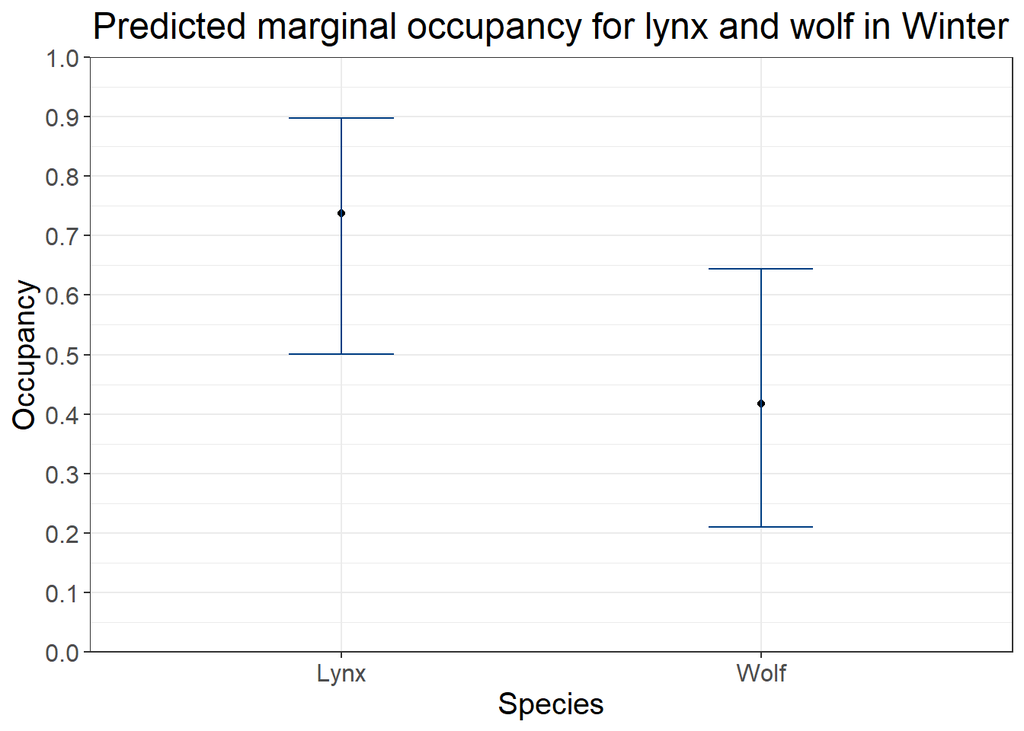

```r
ggplot(
  data = winter_pred.df,
  aes(x = winter_species,
      y = winter_pred))+
  geom_point()+
  geom_errorbar(
    data = winter_pred.df,
    aes(x = winter_species,
        ymin = winter_lower,
        ymax = winter_upper),
    width = 0.25,
    color = '#003E83')+
  scale_y_continuous(
    breaks = seq(0,1,0.1),
    limits = c(0,1),
    expand = c(0,0))+
  labs(
    title = 'Predicted marginal occupancy for lynx and wolf in Winter',
    x = 'Species',
    y = 'Occupancy')+
  theme_bw()+
  theme(
    plot.title = element_text(hjust = 0.5,
                              size = 18),
    axis.text = element_text(size = 12),
    axis.title = element_text(size = 15))
```

# Marginal detection results ——————————————–

Calculate marginal detection using the ‘predict’ function

```r
# lynx
winter_L_md <-
  (predict(winter_LW_203, # the model we want to use to make predictions
           'det', # specifies we want the predicted detection
           species='Lynx')) # specifies the species

mean(winter_L_md$Predicted)
```

```
## [1] 0.2689487
```

```r
# wolf
winter_W_md <-
  (predict(winter_LW_203,
           'det',
           species ='Wolf'))

mean(winter_W_md$Predicted)
```

```
## [1] 0.2032199
```

# Conditional occupancy results —————————————–

Calculate conditional occupancy results (predicted occupancy of one species conditional on the presence/absence of another species) using the ‘predict’ function

```r
# Lynx

# lynx | wolf present
winter_L_co_W <-
  (predict(winter_LW_203,
           'state',
           species='Lynx',
           cond='Wolf'))
```

```
## Bootstrapping confidence intervals with 100 samples
```

```r
mean(winter_L_co_W$Predicted)
```

```
## [1] 0.8292326
```

```r
# lynx | wolf absent
winter_L_noW <-
  (predict(winter_LW_203,
           'state',
           species ='Lynx',
           cond ='-Wolf'))
```

```
## Bootstrapping confidence intervals with 100 samples
```

```r
mean(winter_L_noW$Predicted)
```

```
## [1] 0.6681218
```

```r
# Wolf

# wolf | lynx present
winter_W_co_L<-
  (predict(winter_LW_203,
           'state',
           species ='Wolf',
           cond ='Lynx'))
```

```
## Bootstrapping confidence intervals with 100 samples
```

```r
mean(winter_W_co_L$Predicted)
```

```
## [1] 0.4571832
```

```r
# wolf | lynx absent
winter_W_noL <-
  (predict(winter_LW_203,
           'state',
           species ='Wolf',
           cond ='-Lynx'))
```

```
## Bootstrapping confidence intervals with 100 samples
```

```r
mean(winter_W_noL$Predicted)
```

```
## [1] 0.2867986
```

# Marginal occupancy graphs ———————————————

Rhis section uses package ggplot2. I have provided code to make a marginal occupancy graph for one species based on one variable. You can use the template below to graph other species predictions and other variables

Create new data frame holding all variables constant except the one we want to plot using expand.grid function (in this case, wolf occupancy as a function of elevation). This new data frame must include all variables in the model including both detection on occupancy variables for all species and species combinations

```r
winter_203_Z.df <-
  data.frame(
    expand.grid(
      Z = seq(
        min(winter_sites.scaled$Z),
        max(winter_sites.scaled$Z),
        0.01),
      CLC_forest = mean(winter_sites.scaled$CLC_forest),
      denslocalr = mean(winter_sites.scaled$denslocalr),
      diststream = mean(winter_sites.scaled$diststream)))

# calculate predicted occupancy using the chosen model for a species to add to the new data frame created above
winter_Epsi_203_W <-
  predict(winter_LW_203,
          type ="state",
          species = 'Wolf',
          newdata = winter_203_Z.df)
```

```
## Bootstrapping confidence intervals with 100 samples
```

```r
# combine predicted data from above with new data frame
winter_Epsi_203_W <-
  data.frame(winter_Epsi_203_W,
             denslocalr = winter_203_Z.df$denslocalr,
             Z = winter_203_Z.df$Z,
             CLC_forest = winter_203_Z.df$CLC_forest,
             diststream = winter_203_Z.df$diststream)


winter_Epsi_203_W <-
  winter_Epsi_203_W %>%
  mutate(lwr = Predicted-SE,
         upr = Predicted + SE)

# add raw data for x-axis to new data frame for plotting instead of scaled variable which is hard to interpret
alt <-
  matrix(
    seq(from = 663,
        to = 1600,
        length.out = 447),
    ncol = 1)

# combined
winter_Epsi_203_W <-
  cbind(winter_Epsi_203_W, alt)
```

Create graph

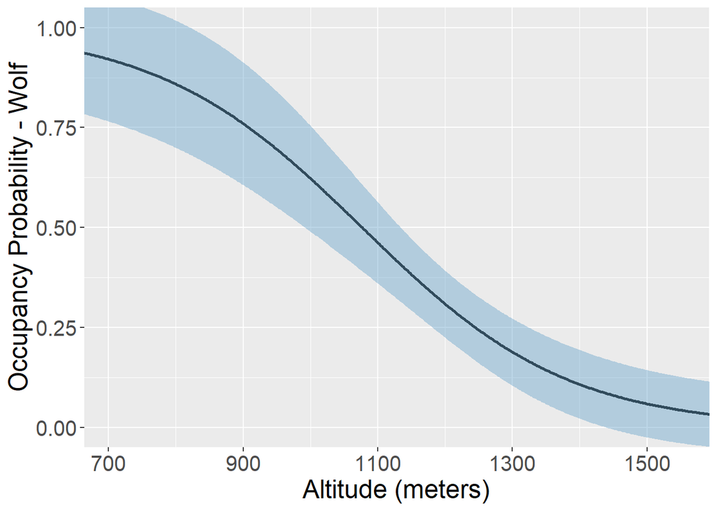

```r
winter_W_Z.plot <- ggplot(data = winter_Epsi_203_W, aes(x = alt,
                                                          y = Predicted)) +

  # add predicted line
  geom_line(linewidth = 1,
            color = "black") +

  # add error ribbon around predicted line
  geom_ribbon( aes(ymin = lwr,
                   ymax = upr),
               alpha = 0.45,
               fill = "skyblue3") +

  # alter axis labels
  xlab ("Altitude (meters)")+
  ylab ("Occupancy Probability - Wolf") +

  # standardize plot area and set breaks
  coord_cartesian(ylim = c(0,1),
                  xlim = c(706,1550)) +
  scale_x_continuous(breaks = seq(700,1600, 200)) +

  # adjust theme elements for pub
  theme(axis.text = element_text(size = 15),
        axis.title = element_text(size = 18))

winter_W_Z.plot
```